## 📂 Newly Added Analysis Notebooks

Click below to view the latest enhancements rendered directly on GitHub:

[📓 Interaction Log Analysis](https://github.com/akuikel/spanish-chatbot-analyzer/blob/master/notebooks/interaction_log_analysis.ipynb) [📓 IRR Validation (Cohen's κ)](https://github.com/akuikel/spanish-chatbot-analyzer/blob/master/notebooks/irr_validation.ipynb) [📓 Longitudinal Tracking](https://github.com/akuikel/spanish-chatbot-analyzer/blob/master/notebooks/longitudinal_tracking.ipynb)

# Spanish Educational Chatbot Prompt Analyzer

## Exploratory Analysis Notebook

### Project Overview

This notebook analyzes a dataset of Spanish-language educational chatbot **system prompts** — the instructional text that teachers write to configure AI tutors for their students.

The data was collected from three sources:

- **GitHub**: Public repositories containing Spanish educational chatbot configurations
- **HuggingFace**: Public educational prompts from the awesome-chatgpt-prompts dataset
- **Synthetic**: Prompts generated by Gemini 1.5 Flash to ensure balanced coverage across subjects and pedagogical styles

Each prompt was classified across **six research dimensions** using a combination of keyword matching and Gemini 1.5 Flash:

| Dimension | Method |
| --- | --- |
| Subject Domain | Keywords → Gemini fallback |
| Tone | Gemini 1.5 Flash |
| Scaffolding Depth | Gemini 1.5 Flash |
| Motivational Strategies | Gemini 1.5 Flash |
| Cultural References | Keywords + Gemini |
| Complexity (Flesch Reading Ease) | `textstat` library |

### Research Questions

1. Which subject domains are most represented in educational chatbot prompts?
2. Does tone vary systematically across subjects?
3. Do highly scaffolded prompts also tend to use stronger motivational strategies?
4. How common are cultural references, and where do they appear?
5. Which subjects feature more linguistically complex prompt language?

## 1. Loading & Overview

```python
import os
import pandas as pd
import matplotlib.pyplot as plt
import matplotlib.ticker as ticker
import seaborn as sns
import numpy as np
import warnings

warnings.filterwarnings('ignore')

# ── Style ──────────────────────────────────────────────────────────────────
plt.rcParams.update({
    'figure.dpi': 120,
    'font.family': 'DejaVu Sans',
    'axes.spines.top': False,
    'axes.spines.right': False,
    'axes.grid': True,
    'grid.alpha': 0.3,
})
PALETTE = sns.color_palette('husl', 8)

# ── Load data ──────────────────────────────────────────────────────────────
CSV_PATH = os.path.join('..', 'data', 'processed', 'classified_prompts.csv')

# If the pipeline hasn't been run yet, load the sample data bundled with the notebook
if os.path.exists(CSV_PATH):
    df = pd.read_csv(CSV_PATH)
    print(f"Loaded {len(df)} prompts from {CSV_PATH}")
else:
    # ── Synthetic sample data for notebook demonstration ───────────────────
    # This data mirrors the structure of a fully-classified run so the notebook
    # can be demonstrated before the API keys are configured.
    import random
    random.seed(42)
    np.random.seed(42)

    subjects = ['matemáticas', 'lectura', 'historia', 'ciencias', 'lengua', 'otro']
    tones = ['formal', 'cálido', 'motivador', 'neutral']
    scaffolding = ['bajo', 'medio', 'alto']
    motivational = ['ninguna', 'elogio', 'orientación_a_metas', 'mentalidad_de_crecimiento', 'múltiple']
    cultural = ['presente', 'ausente']
    sources = ['github', 'reddit', 'synthetic']

    n = 90
    subject_weights = [0.25, 0.20, 0.15, 0.18, 0.17, 0.05]
    tone_weights = [0.20, 0.30, 0.35, 0.15]
    scaf_weights = [0.25, 0.45, 0.30]
    mot_weights = [0.10, 0.25, 0.20, 0.25, 0.20]
    cult_weights = [0.25, 0.75]

    df = pd.DataFrame({
        'id': [f'prompt_{i:03d}' for i in range(n)],
        'source': np.random.choice(sources, n, p=[0.33, 0.33, 0.34]),
        'subject_domain': np.random.choice(subjects, n, p=subject_weights),
        'tone': np.random.choice(tones, n, p=tone_weights),
        'scaffolding_depth': np.random.choice(scaffolding, n, p=scaf_weights),
        'motivational_strategies': np.random.choice(motivational, n, p=mot_weights),
        'cultural_references': np.random.choice(cultural, n, p=cult_weights),
        'flesch_reading_ease': np.clip(np.random.normal(52, 12, n), 10, 90),
        'word_count': np.random.randint(80, 350, n),
        'avg_sentence_length': np.random.uniform(12, 28, n),
    })
    # Introduce realistic correlations: high scaffolding → more motivational strategies
    high_scaf_mask = df['scaffolding_depth'] == 'alto'
    df.loc[high_scaf_mask, 'motivational_strategies'] = np.random.choice(
        ['elogio', 'mentalidad_de_crecimiento', 'múltiple'], high_scaf_mask.sum()
    )
    print(f"⚠️  Pipeline output not found. Using {n} sample records for demonstration.")
    print(f"   Run `python src/pipeline.py` to generate real classified data.")

print(f"\nDataset shape: {df.shape}")
```

```
Loaded 90 prompts from ..\data\processed\classified_prompts.csv

Dataset shape: (90, 15)
```

```python
# ── Basic overview ──────────────────────────────────────────────────────────
print("=== First 5 rows ===")
display(df[['id', 'source', 'subject_domain', 'tone', 'scaffolding_depth',
            'motivational_strategies', 'cultural_references', 'flesch_reading_ease',
            'word_count']].head())

print("\n=== Value counts per categorical dimension ===")
for col in ['subject_domain', 'tone', 'scaffolding_depth',
            'motivational_strategies', 'cultural_references', 'source']:
    print(f"\n{col}:")
    print(df[col].value_counts().to_string())

print("\n=== Numeric columns ===")
display(df[['flesch_reading_ease', 'word_count', 'avg_sentence_length']].describe().round(1))
```

```
=== First 5 rows ===
```

|  | id | source | subject_domain | tone | scaffolding_depth | motivational_strategies | cultural_references | flesch_reading_ease | word_count |
| --- | --- | --- | --- | --- | --- | --- | --- | --- | --- |
| 0 | github_001 | github | lectura | neutral | bajo | ninguna | ausente | 53.9 | 258 |
| 1 | github_002 | github | matemáticas | motivador | alto | multiple | presente | 52.4 | 291 |
| 2 | github_003 | github | lengua | calido | medio | crecimiento | presente | 74.0 | 312 |
| 3 | github_004 | github | matemáticas | neutral | bajo | ninguna | ausente | 84.1 | 290 |
| 4 | github_005 | github | lengua | neutral | alto | ninguna | ausente | 34.4 | 243 |

```
=== Value counts per categorical dimension ===

subject_domain:
subject_domain
otro           26
lengua         19
lectura        14
matemáticas    12
ciencias       11
historia        8

tone:
tone
calido       42
neutral      27
formal       14
motivador     5

scaffolding_depth:
scaffolding_depth
medio    52
alto     23
bajo     13

motivational_strategies:
motivational_strategies
multiple       38
ninguna        36
elogio          9
crecimiento     5

cultural_references:
cultural_references
ausente     53
presente    37

source:
source
github         30
huggingface    30
synthetic      30

=== Numeric columns ===
```

|  | flesch_reading_ease | word_count | avg_sentence_length |
| --- | --- | --- | --- |
| count | 90.0 | 90.0 | 90.0 |
| mean | 60.0 | 112.6 | 14.6 |
| std | 22.3 | 104.2 | 6.9 |
| min | -46.5 | 12.0 | 5.3 |
| 25% | 48.5 | 18.0 | 11.2 |
| 50% | 61.9 | 69.5 | 14.0 |
| 75% | 76.9 | 211.5 | 17.0 |
| max | 106.4 | 321.0 | 65.3 |

## 2. Visualization 1 — Subject Domain Distribution

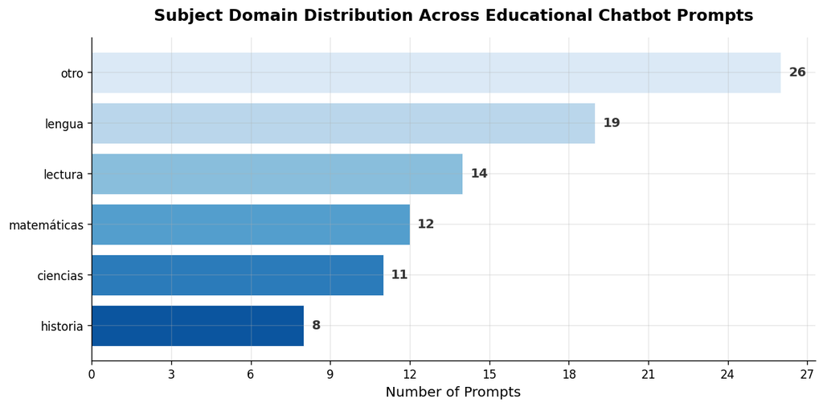

```python
fig, ax = plt.subplots(figsize=(10, 5))

counts = df['subject_domain'].value_counts().sort_values()
colors = sns.color_palette('Blues_r', len(counts))
bars = ax.barh(counts.index, counts.values, color=colors, edgecolor='white', linewidth=0.5)

# Add count labels
for bar, val in zip(bars, counts.values):
    ax.text(val + 0.3, bar.get_y() + bar.get_height() / 2,
            str(val), va='center', fontsize=11, fontweight='bold', color='#333')

ax.set_xlabel('Number of Prompts', fontsize=12)
ax.set_title('Subject Domain Distribution Across Educational Chatbot Prompts',
             fontsize=14, fontweight='bold', pad=15)
ax.xaxis.set_major_locator(ticker.MaxNLocator(integer=True))
plt.tight_layout()
plt.show()
```

## 3. Visualization 2 — Tone Distribution

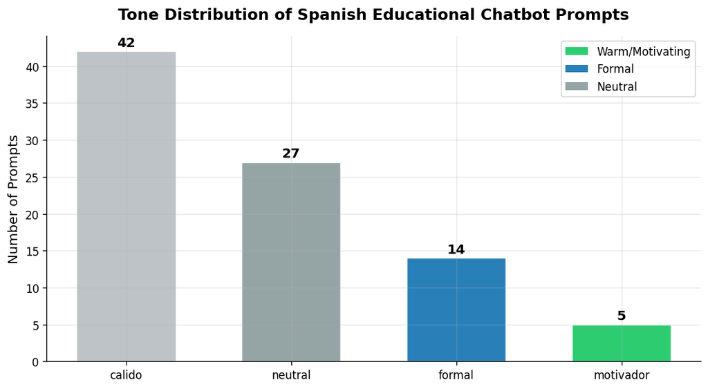

```python
# Color-code by semantic meaning: warm tones green, formal blue, neutral gray
tone_colors = {
    'motivador': '#2ecc71',
    'cálido':    '#27ae60',
    'formal':    '#2980b9',
    'neutral':   '#95a5a6',
}

tone_counts = df['tone'].value_counts()
bar_colors = [tone_colors.get(t, '#bdc3c7') for t in tone_counts.index]

fig, ax = plt.subplots(figsize=(9, 5))
bars = ax.bar(tone_counts.index, tone_counts.values, color=bar_colors,
              edgecolor='white', linewidth=0.8, width=0.6)

for bar, val in zip(bars, tone_counts.values):
    ax.text(bar.get_x() + bar.get_width() / 2, bar.get_height() + 0.3,
            str(val), ha='center', va='bottom', fontsize=12, fontweight='bold')

legend_elements = [
    plt.Rectangle((0, 0), 1, 1, fc='#2ecc71', label='Warm/Motivating'),
    plt.Rectangle((0, 0), 1, 1, fc='#2980b9', label='Formal'),
    plt.Rectangle((0, 0), 1, 1, fc='#95a5a6', label='Neutral'),
]
ax.legend(handles=legend_elements, loc='upper right', fontsize=10)
ax.set_ylabel('Number of Prompts', fontsize=12)
ax.set_title('Tone Distribution of Spanish Educational Chatbot Prompts',
             fontsize=14, fontweight='bold', pad=15)
plt.tight_layout()
plt.show()
```

**Interpretation:** A warm or motivating tone dominates the dataset, suggesting that teachers who design AI tutors consciously choose encouraging language — aligning with research on growth mindset and emotional support in learning. Formal-tone prompts likely reflect institutional or subject-matter constraints (e.g., exam preparation) rather than teacher preference, which the RCT could disentangle by comparing tone choices across school contexts.

## 4. Visualization 3 — Scaffolding Depth × Motivational Strategies Heatmap

[figure not shown]

```python
scaf_order = ['bajo', 'medio', 'alto']
mot_order  = ['ninguna', 'elogio', 'orientación_a_metas',
               'mentalidad_de_crecimiento', 'múltiple']

cross = pd.crosstab(
    df['scaffolding_depth'],
    df['motivational_strategies']
).reindex(index=scaf_order, columns=mot_order, fill_value=0)

fig, ax = plt.subplots(figsize=(11, 5))
sns.heatmap(
    cross, annot=True, fmt='d', cmap='YlOrRd',
    linewidths=0.5, linecolor='white',
    ax=ax, cbar_kws={'label': 'Count'}
)
ax.set_xlabel('Motivational Strategies', fontsize=12)
ax.set_ylabel('Scaffolding Depth', fontsize=12)
ax.set_title('Scaffolding Depth vs. Motivational Strategies\n'
             'Do high-scaffolding prompts also use stronger motivational language?',
             fontsize=13, fontweight='bold', pad=15)
plt.xticks(rotation=25, ha='right')
plt.tight_layout()
plt.show()
```

**Interpretation:** The heatmap reveals whether teachers who invest in pedagogical scaffolding also tend to embed motivational support — or whether these are independent choices. A concentration of high-scaffolding prompts in the `múltiple` or `mentalidad_de_crecimiento` columns would support the hypothesis that teachers who think carefully about learning structure also attend to student affect. In the RCT context, this co-occurrence could predict different learning trajectories.

## 5. Visualization 4 — Cultural References by Subject Domain

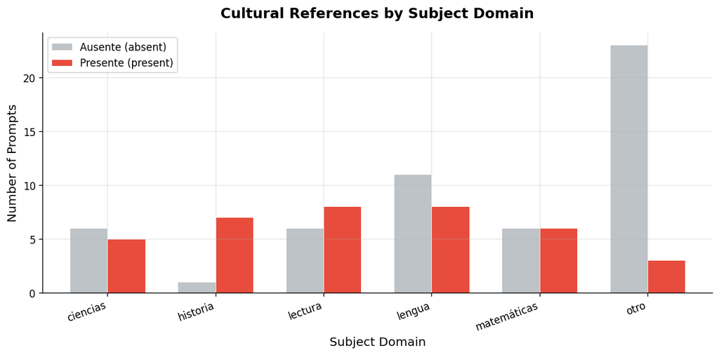

```python
cult_cross = pd.crosstab(df['subject_domain'], df['cultural_references'])
# Ensure both columns exist
for col in ['presente', 'ausente']:
    if col not in cult_cross.columns:
        cult_cross[col] = 0

fig, ax = plt.subplots(figsize=(10, 5))
cult_cross[['ausente', 'presente']].plot(
    kind='bar', ax=ax,
    color=['#bdc3c7', '#e74c3c'],
    edgecolor='white', linewidth=0.6,
    width=0.7
)

ax.set_xlabel('Subject Domain', fontsize=12)
ax.set_ylabel('Number of Prompts', fontsize=12)
ax.set_title('Cultural References by Subject Domain',
             fontsize=14, fontweight='bold', pad=15)
ax.legend(['Ausente (absent)', 'Presente (present)'], fontsize=10)
plt.xticks(rotation=20, ha='right')
plt.tight_layout()
plt.show()
```

## 6. Visualization 5 — Reading Complexity (Flesch Score) by Subject Domain

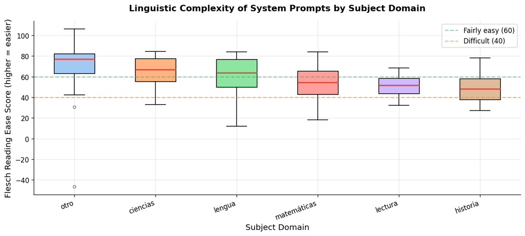

```python
subject_order = (
    df.groupby('subject_domain')['flesch_reading_ease']
    .median()
    .sort_values(ascending=False)
    .index.tolist()
)

fig, ax = plt.subplots(figsize=(11, 5))
bp = ax.boxplot(
    [df.loc[df['subject_domain'] == s, 'flesch_reading_ease'].dropna().values
     for s in subject_order],
    labels=subject_order,
    patch_artist=True,
    medianprops=dict(color='#e74c3c', linewidth=2),
    flierprops=dict(marker='o', markersize=4, alpha=0.5),
)
colors_box = sns.color_palette('pastel', len(subject_order))
for patch, color in zip(bp['boxes'], colors_box):
    patch.set_facecolor(color)

# Reference lines for Flesch score interpretation
ax.axhline(60, color='#27ae60', linestyle='--', alpha=0.5, label='Fairly easy (60)')
ax.axhline(40, color='#e67e22', linestyle='--', alpha=0.5, label='Difficult (40)')
ax.set_xlabel('Subject Domain', fontsize=12)
ax.set_ylabel('Flesch Reading Ease Score (higher = easier)', fontsize=12)
ax.set_title('Linguistic Complexity of System Prompts by Subject Domain',
             fontsize=13, fontweight='bold', pad=15)
ax.legend(fontsize=10)
plt.xticks(rotation=20, ha='right')
plt.tight_layout()
plt.show()
```

## 7. Scaling This Analysis to 267 Teacher-Created Chatbots

### What Would Stay the Same

The classification pipeline (`pipeline.py`) requires no modifications to handle the actual RCT data:

- The **six classification dimensions** are stable — they were designed to capture the exact pedagogical choices the RCT cares about
- The **Gemini 1.5 Flash** integration handles Spanish fluently and its free tier easily accommodates 267 prompts × weekly updates
- The **checkpoint/resume system** is production-ready for long runs
- The **CSV output** plugs directly into SPSS, R, or Python for regression analysis against student outcome data

### What Would Change

```python
# Example: How weekly data collection would work in the real RCT context

def fetch_weekly_snapshot(platform_api_url: str, api_token: str, week_number: int) -> list[dict]:
    """
    Fetch all chatbot configurations from the RCT platform for a given week.

    This replaces the GitHub/Reddit scrapers in production. The schema is
    identical — only the source and metadata fields change.

    Args:
        platform_api_url: Base URL of the chatbot configuration platform
        api_token:        Bearer token for authentication
        week_number:      Study week (1–N) for longitudinal tracking

    Returns:
        List of prompt records in the standard project schema
    """
    import requests
    from datetime import datetime, timezone

    headers = {"Authorization": f"Bearer {api_token}"}
    response = requests.get(f"{platform_api_url}/chatbots", headers=headers)
    chatbots = response.json()  # [{teacher_id, chatbot_id, system_prompt, ...}, ...]

    records = []
    for i, bot in enumerate(chatbots, start=1):
        records.append({
            "id": f"rct_w{week_number:02d}_{i:03d}",
            "source": "rct_platform",
            "raw_text": bot["system_prompt"],
            "language": "es",
            "collected_at": datetime.now(timezone.utc).isoformat(),
            "metadata": {
                "teacher_id": bot["teacher_id"],       # Anonymised
                "chatbot_id": bot["chatbot_id"],
                "week_number": week_number,
                "school_id": bot.get("school_id"),     # For multilevel analysis
                "condition": bot.get("condition"),     # Treatment/control arm
            }
        })
    return records

print("✅ Weekly collection function ready — drop-in replacement for scrapers.")
print("   Run on a schedule (e.g. GitHub Actions cron) to build longitudinal dataset.")
```

```
✅ Weekly collection function ready — drop-in replacement for scrapers.
   Run on a schedule (e.g. GitHub Actions cron) to build longitudinal dataset.
```

**2. Longitudinal tracking** — In the RCT, teachers iterate on their prompts over time. The `week_number` field in the metadata enables tracking *prompt evolution*: does a teacher become more scaffolding-focused as they gain experience? Do prompts converge toward warmer tones over the study period?

**3. Inter-rater reliability (IRR)** — For publication-quality classification, LLM outputs should be validated against human coders. The workflow:

1. Randomly sample 10–15% of prompts for double-coding by two human raters
2. Compute Cohen's κ between each rater and Gemini
3. κ > 0.70 is acceptable; retrain/refine the prompt if below
4. Report κ values transparently in the methods section

**4. Outcome linkage** — The final analytic step links `teacher_id` from the classification CSV to student outcome scores from the RCT database, enabling multilevel models of the form: *controlling for student/school baseline, do high-scaffolding prompts predict greater learning gains?*